# Animal Behavior Analysis: Comparing Healthy and Vestibular Syndrome Rats

# Background

The study of animal behavior under controlled experimental conditions offers a unique window to explore how physical variables can reveal crucial aspects of adaptation and behavioral phenomena under different conditions. This approach allows us to analyze how biological alterations, such as those of the vestibular system, affect both locomotion dynamics and environmental sensing, as well as behavioral adaptation in static and dynamic environments.

Physical variables, such as displacement velocity, trajectory patterns, and efficiency in performing temporo-spatial learning tasks (i.e., when and where a resource is delivered), offer a precise and quantitative measure of how subjects adapt their behavior under specific biological conditions. This multidimensional approach not only broadens our understanding of the mechanisms underlying behavioral adaptations and phenomena but could also have significant implications for developing therapeutic interventions and improving quality of life in cases of neurological disorders.

In this context, our study explores the use of physical variables to identify distinctive patterns of behavior between healthy subjects and those with vestibular syndrome (VS). This approach provides a more comprehensive view of the complexities in the integration of locomotion and spatio-temporal learning.

## Objective

To compare behavioral dynamics in healthy Wistar rats and rats with vestibular syndrome by analyzing associated physical variables, such as displacement velocity, trajectory patterns, and location density, under reinforcement programs contingent on the organisms’ displacement (FD/VD 100cm), using an expanded experimental chamber for water delivery.

# Method

## Subjects

Four 4-5 month old female Wistar rats, experimentally naive, two healthy (H) and two with vestibular syndrome (VS), water-deprived for 23 hours.

## Apparatus

Functional Space Densification Apparatus (FSDA), 100 x 100 x 40 cm with uniform black walls and floor.

## Procedure

Subjects were grouped according to their biological condition: H rats (R1;R2) and VS rats (R3;R4). All subjects were exposed to two phases, presented in random sequence: VD (Variable Distance) and FD (Fixed Distance). In the VD phase, water (3ml, available for 3”) was delivered each time the subject met a previously established distance criterion, which varied reaching an average of 100cm at the end of the session. The FD phase was similar, but water was delivered under a fixed criterion every time the subject traveled 100cm. The continuous displacement of the subjects was recorded through the coordinates (X,Y) of the center of mass, at a frequency of 5 Hz.

# Script setup

```r
# Load required libraries
library(tidyverse)
library(readr)
library(ggplot2)
library(plotly)
library(lubridate)
library(zoo)
library(viridis)
library(entropy)
library(fractaldim)
library(stats)
library(purrr)
library(data.table)
library(rayshader)
library(dplyr)

# Function to read and preprocess data
read_and_preprocess <- function(file_path) {
  data <- fread(file_path, skip = 12)

  # Ensure column names exist and select them
  if(all(c("Time", "X", "Y") %in% names(data))) {
    data <- data[, .(Time, X, Y)]
  } else {
    stop("Required columns (Time, X, Y) not found in the data")
  }

  # Add additional columns
  data[, `:=`(
    file = basename(file_path),
    rat = substr(basename(file_path), 1, 2),
    condition = ifelse(grepl("DV", basename(file_path)), "DV", "DF"),
    session = as.numeric(gsub(".*s(\\d+).*", "\\1", basename(file_path))),
    health_status = ifelse(grepl("Síndrome Vestibular", file_path), "Enferma", "Sana")
  )]

  return(data)
}

# Read all files from S3 and S4 directories (healthy rats)
s3_files <- list.files("/home/thermostatic/Desktop/Ratas/datos/Sanas/S3", full.names = TRUE, pattern = "*.csv")
s4_files <- list.files("/home/thermostatic/Desktop/Ratas/datos/Sanas/S4", full.names = TRUE, pattern = "*.csv")

# Read all files from S2 and S5 directories (sick rats)
s2_files <- list.files("/home/thermostatic/Desktop/Ratas/datos/Síndrome Vestibular/S2", full.names = TRUE, pattern = "*.csv")
s5_files <- list.files("/home/thermostatic/Desktop/Ratas/datos/Síndrome Vestibular/S5", full.names = TRUE, pattern = "*.csv")

all_files <- c(s3_files, s4_files, s2_files, s5_files)

# Use tryCatch to handle potential errors
all_data <- tryCatch({
  rbindlist(lapply(all_files, read_and_preprocess), fill = TRUE)
}, error = function(e) {
  print(paste("Error:", e$message))
  return(NULL)
})

# Check if data was loaded successfully before proceeding
if (!is.null(all_data)) {
  # Calculate velocity and acceleration
  all_data[, c("delta_t", "Displacement_X", "Displacement_Y", "Displacement_Magnitude",
               "Velocity_X", "Velocity_Y", "Velocity_Magnitude",
               "Acceleration_X", "Acceleration_Y", "Acceleration_Magnitude") := {
    delta_t <- Time - shift(Time)
    Displacement_X <- X - shift(X)
    Displacement_Y <- Y - shift(Y)
    Displacement_Magnitude <- sqrt(Displacement_X^2 + Displacement_Y^2)
    Velocity_X <- (X - shift(X)) / delta_t
    Velocity_Y <- (Y - shift(Y)) / delta_t
    Velocity_Magnitude <- sqrt(Velocity_X^2 + Velocity_Y^2)
    Acceleration_X <- (Velocity_X - shift(Velocity_X)) / delta_t
    Acceleration_Y <- (Velocity_Y - shift(Velocity_Y)) / delta_t
    Acceleration_Magnitude <- sqrt(Acceleration_X^2 + Acceleration_Y^2)
    list(delta_t, Velocity_X, Velocity_Y, Velocity_Magnitude,
         Acceleration_X, Acceleration_Y, Acceleration_Magnitude)
  }, by = .(rat, condition, session, health_status)]
}
```

```r
# Define the color palette
color_palette <- c("#c16e6d", "#a1493d", "#1a1a22", "#404064", "#563d5b")

# Function to remove outliers
remove_outliers <- function(x, k = 1.5) {
  qnt <- quantile(x, probs=c(.25, .75), na.rm = TRUE)
  H <- k * IQR(x, na.rm = TRUE)
  y <- x
  y[x < (qnt[1] - H)] <- NA
  y[x > (qnt[2] + H)] <- NA
  return(y)
}
```

```r
# Apply remove_outliers to velocity and acceleration data
all_data[, `:=`(
  Displacement_Magnitude = remove_outliers(Displacement_Magnitude),
  Velocity_Magnitude = remove_outliers(Velocity_Magnitude),
  Acceleration_Magnitude = remove_outliers(Acceleration_Magnitude)
)]
```

```r
# Filter out NA values from Velocity_Magnitude, Acceleration_Magnitude, and Displacement_Magnitude
cleaned_data <- all_data[!is.na(Velocity_Magnitude) & !is.na(Acceleration_Magnitude) & !is.na(Displacement_Magnitude)]
```

```r
# Function to plot displacement distribution
plot_displacement_distribution <- function(data) {
  ggplot(data, aes(x = Displacement_Magnitude, fill = health_status)) +
    geom_density(alpha = 0.7) +
    facet_grid(condition ~ ., scales = "free_y") +
    scale_fill_manual(values = color_palette[c(1, 4)]) +
    labs(title = "Distribución de magnitudes de los desplazamientos",
         x = "Magnitud del desplazamiento (cm)",
         y = "Densidad",
         fill = "Estado de salud") +
    theme_minimal(base_size = 14) +
    theme(
      plot.title = element_text(hjust = 0.5, face = "bold"),
      legend.position = "bottom",
      panel.grid.minor = element_blank(),
      panel.border = element_rect(color = "black", fill = NA, size = 0.5),
      strip.background = element_rect(fill = color_palette[3], color = NA),
      strip.text = element_text(color = "white", face = "bold")
    )
}
```

```r
# Function to plot velocity distribution
plot_velocity_distribution <- function(data) {
  ggplot(data, aes(x = Velocity_Magnitude, fill = health_status)) +
    geom_density(alpha = 0.7) +
    facet_grid(condition ~ ., scales = "free_y") +
    scale_fill_manual(values = color_palette[c(1, 4)]) +
    labs(title = "Distribución de magnitudes de las velocidades",
         x = "Magnitud de la velocidad (cm/s)",
         y = "Densidad",
         fill = "Estado de salud") +
    theme_minimal(base_size = 14) +
    theme(
      plot.title = element_text(hjust = 0.5, face = "bold"),
      legend.position = "bottom",
      panel.grid.minor = element_blank(),
      panel.border = element_rect(color = "black", fill = NA, size = 0.5),
      strip.background = element_rect(fill = color_palette[3], color = NA),
      strip.text = element_text(color = "white", face = "bold")
    )
}
```

```r
# Function to plot acceleration distribution
plot_acceleration_distribution <- function(data) {
  ggplot(data, aes(x = Acceleration_Magnitude, fill = health_status)) +
    geom_density(alpha = 0.7) +
    facet_grid(condition ~ ., scales = "free_y") +
    scale_fill_manual(values = color_palette[c(1, 4)]) +
    labs(title = "Distribución de magnitudes de las aceleraciones",
         x = "Magnitud de la aceleración (cm/s^2)",
         y = "Densidad",
         fill = "Estado de salud") +
    theme_minimal(base_size = 14) +
    theme(
      plot.title = element_text(hjust = 0.5, face = "bold"),
      legend.position = "bottom",
      panel.grid.minor = element_blank(),
      panel.border = element_rect(color = "black", fill = NA, size = 0.5),
      strip.background = element_rect(fill = color_palette[3], color = NA),
      strip.text = element_text(color = "white", face = "bold")
    )
}
```

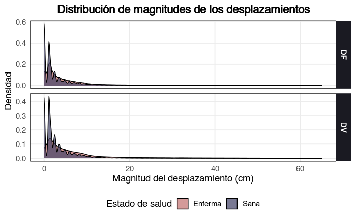

```r
# Plot displacement distribution
plot_displacement_distribution(cleaned_data)
```

This image shows density distribution plots comparing displacement magnitudes between healthy (Sana) and VS-affected (Enferma) rats under two different conditions: DF (Fixed Distance) and DV (Variable Distance), shown in the top and bottom panels respectively.

The x-axis represents the magnitude of displacement in centimeters (up to about 70cm), while the y-axis shows the density or frequency of these displacements. The plots reveal several interesting patterns:

1. In both DF and DV conditions, there’s a pronounced peak in displacement magnitude at very short distances (around 0-5cm), suggesting frequent small movements by both groups.
2. The distributions follow a right-skewed pattern, with frequency decreasing as displacement magnitude increases.
3. There appear to be subtle differences between healthy and VS-affected rats, particularly in the height and shape of the initial peaks.
4. The DF condition (top panel) shows slightly higher density values overall compared to the DV condition (bottom panel), suggesting more consistent movement patterns under fixed distance requirements.
5. Both groups show similar general patterns of movement distribution, though with some variations in the specific details of their distributions.

This visualization effectively captures the quantitative differences in movement patterns between healthy and VS-affected rats under different experimental conditions, providing valuable insights into how vestibular syndrome affects locomotor behavior.

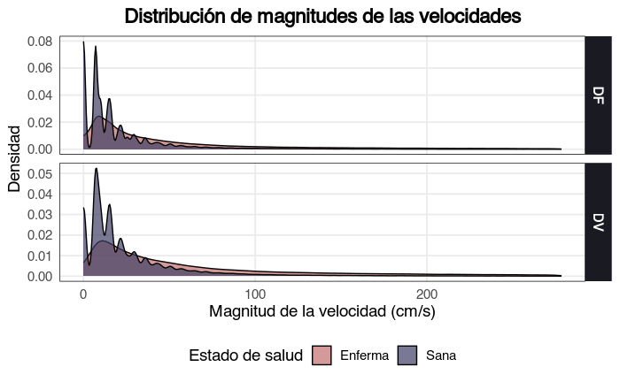

```r
# Plot velocity distribution
plot_velocity_distribution(cleaned_data)
```

This image shows the distribution of velocity magnitudes for both healthy (Sana) and VS-affected (Enferma) rats, again under both Fixed Distance (DF) and Variable Distance (DV) conditions. There are several key observations:

1. The x-axis now shows velocity in cm/s (extending to about 300 cm/s), while the y-axis shows the density of these velocity measurements.
2. Similar to the displacement plot, there are multiple peaks in the velocity distributions, particularly at lower velocities (around 0-50 cm/s), suggesting preferred movement speeds.
3. The healthy rats appear to show more distinct peaks in their velocity distribution, particularly in the DF condition, which might indicate more controlled or structured movement patterns.
4. The distributions are again right-skewed, with most velocities concentrated in the lower ranges and a long tail extending into higher velocities.
5. The DF condition (top panel) shows slightly different velocity patterns compared to the DV condition (bottom panel), with somewhat higher and more distinct peaks.

This visualization complements the previous displacement plot by showing how the rats’ movement speeds vary under different conditions. The differences between healthy and VS-affected rats are particularly interesting in terms of their preferred movement velocities and the overall structure of their speed distributions.

The multiple peaks in the velocity distributions might represent different modes of movement (like walking, running, or quick turns), and the differences between healthy and VS-affected rats in these patterns could reflect how vestibular syndrome impacts movement control and speed selection.

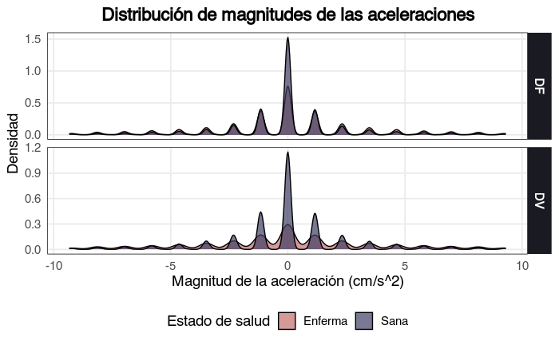

```r
# Plot acceleration distribution
plot_acceleration_distribution(cleaned_data)
```

This acceleration distribution plot is particularly interesting as it reveals some striking patterns:

1. The x-axis shows acceleration in cm/s², ranging from -10 to +10, with 0 at the center, allowing us to see both acceleration and deceleration patterns.
2. The most notable feature is the prominent central peak at 0 acceleration, indicating a strong tendency for steady-state movement (constant velocity) in both groups.
3. The distribution shows clear symmetrical patterns around 0, with multiple distinctive peaks on both positive and negative sides, suggesting systematic patterns of acceleration and deceleration.
4. There are marked differences between DF (top) and DV (bottom) conditions:
   - The DF condition shows sharper, more defined peaks
   - The DV condition shows broader, more spread-out distributions
5. Most notably, there are clear differences between healthy (Sana) and VS-affected (Enferma) rats:
   - Healthy rats show higher, more defined peaks
   - VS-affected rats show more spread-out distributions with lower peaks
   - These differences are particularly evident in the secondary peaks on either side of the central peak

This graph effectively captures how vestibular syndrome affects movement control - the less defined peaks in VS-affected rats suggest less precise control over acceleration and deceleration, which is consistent with vestibular system impairment affecting balance and movement coordination. The multiple symmetric peaks might represent characteristic movement patterns or strategies used by the rats during their exploration and task completion.

```r
# Summary statistics function
summarize_stats <- function(data) {
  data %>%
    group_by(health_status, condition) %>%
    summarise(
      mean_disp = mean(Displacement_Magnitude, na.rm = TRUE),
      median_disp = median(Displacement_Magnitude, na.rm = TRUE),
      sd_disp = sd(Displacement_Magnitude, na.rm = TRUE),
      iqr_disp = IQR(Displacement_Magnitude, na.rm = TRUE),
      mean_vel = mean(Velocity_Magnitude, na.rm = TRUE),
      median_vel = median(Velocity_Magnitude, na.rm = TRUE),
      sd_vel = sd(Velocity_Magnitude, na.rm = TRUE),
      iqr_vel = IQR(Velocity_Magnitude, na.rm = TRUE),
      mean_acc = mean(Acceleration_Magnitude, na.rm = TRUE),
      median_acc = median(Acceleration_Magnitude, na.rm = TRUE),
      sd_acc = sd(Acceleration_Magnitude, na.rm = TRUE),
      iqr_acc = IQR(Acceleration_Magnitude, na.rm = TRUE)
    )
}

# Calculate summary statistics
summary_stats <- summarize_stats(cleaned_data)
print(summary_stats)
```

| health_status | condition | mean_disp | median_disp | sd_disp | iqr_disp | mean_vel | median_vel | sd_vel | iqr_vel | mean_acc | median_acc | sd_acc | iqr_acc |
| --- | --- | --- | --- | --- | --- | --- | --- | --- | --- | --- | --- | --- | --- |
| Enferma | DF | 7.505549 | 3.235284 | 11.531678 | 6.917415 | 49.87874 | 26.23409 | 58.06481 | 54.48675 | -0.03820203 | 0 | 3.402449 | 2.348818 |
| Enferma | DV | 9.832805 | 4.767286 | 13.186600 | 9.089844 | 61.51624 | 36.69255 | 63.62030 | 68.99195 | -0.01118778 | 0 | 3.816130 | 4.598547 |
| Sana | DF | 3.297942 | 1.173034 | 5.965106 | 3.663798 | 20.83470 | 10.16772 | 29.63661 | 18.28951 | -0.05511653 | 0 | 2.465620 | 2.214886 |
| Sana | DV | 3.766317 | 1.657339 | 5.956398 | 3.538245 | 27.37886 | 15.54694 | 35.32698 | 25.92457 | -0.04633012 | 0 | 2.742327 | 2.320261 |

From the summary statistics, we can observe several differences between healthy and VS-affected rats in terms of displacement, velocity, and acceleration magnitudes across both DF (fixed distance) and DV (variable distance) conditions.

**Velocity Magnitude:**

- **Healthy Rats (Sana):**
  - **DF Condition:** Mean velocity magnitude of about 20.8 cm/s and median of approximately 10.2 cm/s. Standard deviation of approximately 29.6 cm/s and an interquartile range of about 18.3 cm/s.
  - **DV Condition:** Mean velocity magnitude of around 27.4 cm/s and median of about 15.5 cm/s. Standard deviation of approximately 35.3 cm/s and an interquartile range of about 25.9 cm/s.
- **VS-affected Rats (Enferma):**
  - **DF Condition:** Mean velocity magnitude of approximately 49.9 cm/s and median of about 26.2 cm/s. Standard deviation of approximately 58.1 cm/s and an interquartile range of about 54.5 cm/s.
  - **DV Condition:** Mean velocity magnitude of around 61.5 cm/s and median of about 36.7 cm/s. Standard deviation of approximately 63.6 cm/s and an interquartile range of about 69.0 cm/s.

**Acceleration Magnitude:**

- **Healthy Rats (Sana):**
  - **DF Condition:** Mean acceleration of approximately -0.055 cm/s² and median of 0 cm/s². Standard deviation of approximately 2.5 cm/s² and an interquartile range of about 2.2 cm/s².
  - **DV Condition:** Mean acceleration of around -0.046 cm/s² and median of 0 cm/s². Standard deviation of approximately 2.7 cm/s² and an interquartile range of about 2.3 cm/s².
- **VS-affected Rats (Enferma):**
  - **DF Condition:** Mean acceleration of approximately -0.038 cm/s² and median of 0 cm/s². Standard deviation of approximately 3.4 cm/s² and an interquartile range of about 2.3 cm/s².
  - **DV Condition:** Mean acceleration of around -0.011 cm/s² and median of 0 cm/s². Standard deviation of approximately 3.8 cm/s² and an interquartile range of about 4.6 cm/s².

Based on the summary statistics and their relationship with the plots, several key insights emerge:

1. **Movement Magnitude Differences:**
- VS-affected rats show consistently larger displacement magnitudes (roughly 2-2.5 times higher) than healthy rats in both conditions
- This aligns with the displacement distribution plots, where VS-affected rats show broader distributions with more substantial movements
- This suggests that VS-affected rats may have less precise movement control, requiring larger movements to accomplish the same tasks
2. **Velocity Patterns:**
- VS-affected rats exhibit notably higher velocities (approximately 2.3-2.4 times higher means) compared to healthy rats
- The larger standard deviations and IQRs in VS-affected rats (about twice those of healthy rats) indicate more variable movement speeds
- This corresponds to the velocity distribution plots, where VS-affected rats show broader, more dispersed distributions
- These patterns suggest less controlled movement in VS-affected rats, possibly compensating for balance issues with faster, more variable movements
3. **Acceleration Characteristics:**
- Both groups show median accelerations of 0, corresponding to the central peaks in the acceleration distributions
- VS-affected rats show larger standard deviations in acceleration (3.4-3.8 cm/s² vs 2.5-2.7 cm/s² for healthy rats)
- This matches the acceleration plots, where VS-affected rats display more spread-out distributions
- The pattern suggests less steady movement control in VS-affected rats, with more frequent changes in velocity
4. **Condition Effects (DF vs DV):**
- Both groups show slightly higher values in DV compared to DF conditions across all measures
- This difference is consistent with the nature of the tasks, where variable distance requirements might demand more adaptive movement patterns
- The effect is visible in all three distribution plots, where DV conditions show slightly broader distributions
5. **Movement Control Implications:**
- The statistics and plots together suggest that VS-affected rats exhibit:
  - Less precise movement control
  - More variable movement patterns
  - Compensation strategies involving larger movements and higher speeds
  - Less stable acceleration patterns
- These patterns are consistent with vestibular system impairment affecting balance and spatial orientation

This quantitative analysis provides strong evidence for how vestibular syndrome affects movement patterns and behavioral adaptations in rats, showing clear differences in both the magnitude and variability of their movements.

```r
t_test_displacement_df <- t.test(Displacement_Magnitude ~ health_status, data = cleaned_data, subset = condition == "DF")

t_test_displacement_dv <- t.test(Displacement_Magnitude ~ health_status, data = cleaned_data, subset = condition == "DV")

print(t_test_displacement_df)
```

```
    Welch Two Sample t-test

data:  Displacement_Magnitude by health_status
t = 133.88, df = 209283, p-value < 2.2e-16
alternative hypothesis: true difference in means between group Enferma and group Sana is not equal to 0
95 percent confidence interval:
 4.146008 4.269207
sample estimates:
mean in group Enferma    mean in group Sana
             7.505549              3.297942
```

```r
print(t_test_displacement_dv)
```

```
    Welch Two Sample t-test

data:  Displacement_Magnitude by health_status
t = 162.34, df = 171121, p-value < 2.2e-16
alternative hypothesis: true difference in means between group Enferma and group Sana is not equal to 0
95 percent confidence interval:
 5.993246 6.139730
sample estimates:
mean in group Enferma    mean in group Sana
             9.832805              3.766317
```

These t-test results provide strong statistical evidence for the differences between healthy and VS-affected rats’ movement patterns. Let’s analyze the results in detail:

For Fixed Distance (DF) Condition: 1. The test statistic t = 133.88 is extremely large, indicating a substantial difference between groups 2. The difference in means is approximately 4.21 cm (7.51 cm for VS-affected vs 3.30 cm for healthy rats) 3. The 95% confidence interval [4.15, 4.27] is narrow and entirely positive 4. The p-value < 2.2e-16 indicates extremely strong statistical significance

For Variable Distance (DV) Condition: 1. The test statistic t = 162.34 is even larger than in the DF condition 2. The difference in means is larger at approximately 6.07 cm (9.83 cm for VS-affected vs 3.77 cm for healthy rats) 3. The 95% confidence interval [5.99, 6.14] is again narrow and entirely positive 4. The p-value < 2.2e-16 also indicates extremely strong statistical significance

Key Implications: 1. **Statistical Significance**: Both tests show overwhelming evidence (p < 2.2e-16) that the differences between healthy and VS-affected rats are not due to chance

2. **Effect Size**:
   - In DF: VS-affected rats move on average 4.21 cm more per displacement
   - In DV: The difference increases to 6.07 cm per displacement
   - These differences are substantial considering the average displacement magnitudes
3. **Condition Comparison**:
   - The larger t-statistic in DV condition (162.34 vs 133.88) suggests the difference between groups is even more pronounced under variable distance requirements
   - Both groups show slightly larger displacements in DV compared to DF conditions
4. **Precision**:
   - The narrow confidence intervals indicate high precision in estimating the true population differences
   - This high precision is partly due to the large sample sizes (df > 170,000)
5. **Clinical Relevance**:
   - The results quantitatively confirm that vestibular syndrome significantly affects movement patterns
   - The larger differences in the DV condition suggest that VS-affected rats have more difficulty adapting to variable requirements

These statistical results strongly support the observational and descriptive findings, providing robust evidence for the impact of vestibular syndrome on rat movement patterns.

```r
t_test_velocity_df <- t.test(Velocity_Magnitude ~ health_status, data = cleaned_data, subset = condition == "DF")
t_test_velocity_dv <- t.test(Velocity_Magnitude ~ health_status, data = cleaned_data, subset = condition == "DV")

print(t_test_velocity_df)
```

```
    Welch Two Sample t-test

data:  Velocity_Magnitude by health_status
t = 183.88, df = 207901, p-value < 2.2e-16
alternative hypothesis: true difference in means between group Enferma and group Sana is not equal to 0
95 percent confidence interval:
 28.73445 29.35363
sample estimates:
mean in group Enferma    mean in group Sana
             49.87874              20.83470
```

```r
print(t_test_velocity_dv)
```

```
    Welch Two Sample t-test

data:  Velocity_Magnitude by health_status
t = 184.56, df = 187807, p-value < 2.2e-16
alternative hypothesis: true difference in means between group Enferma and group Sana is not equal to 0
95 percent confidence interval:
 33.77485 34.49990
sample estimates:
mean in group Enferma    mean in group Sana
             61.51624              27.37886
```

These velocity t-test results provide additional compelling evidence of movement differences between healthy and VS-affected rats. Let’s analyze these results in detail:

For Fixed Distance (DF) Condition: 1. The test statistic t = 183.88 is extremely large, even higher than for displacement 2. The mean velocity difference is approximately 29.04 cm/s (49.88 cm/s for VS-affected vs 20.83 cm/s for healthy rats) 3. The 95% confidence interval [28.73, 29.35] is narrow and entirely positive 4. The p-value < 2.2e-16 indicates extremely strong statistical significance

For Variable Distance (DV) Condition: 1. The test statistic t = 184.56 is slightly larger than in the DF condition 2. The mean velocity difference increases to approximately 34.14 cm/s (61.52 cm/s for VS-affected vs 27.38 cm/s for healthy rats) 3. The 95% confidence interval [33.77, 34.50] is narrow and entirely positive 4. The p-value < 2.2e-16 also indicates extremely strong statistical significance

Key Implications:

1. **Magnitude of Difference**:
   - VS-affected rats move at speeds roughly 2.4 times faster than healthy rats in DF condition
   - This ratio is similar (2.2 times faster) in the DV condition
   - These differences are substantial and consistent across conditions
2. **Condition Effects**:
   - Both groups show higher velocities in DV compared to DF conditions
   - VS-affected: 61.52 cm/s (DV) vs 49.88 cm/s (DF)
   - Healthy: 27.38 cm/s (DV) vs 20.83 cm/s (DF)
   - This suggests that variable distance requirements lead to faster movements in both groups
3. **Statistical Robustness**:
   - The very large t-statistics (>180 for both conditions) indicate extremely robust differences
   - The narrow confidence intervals suggest high precision in these estimates
   - The large degrees of freedom (>180,000) provide high statistical power
4. **Behavioral Implications**:
   - The consistently higher velocities in VS-affected rats might represent:
     - Compensatory mechanisms for balance issues
     - Less precise movement control
     - Different movement strategies to accomplish the same tasks
   - The increased velocities in DV conditions might reflect:
     - Greater movement urgency under variable requirements
     - Different strategic approaches to unpredictable situations
5. **Clinical Significance**:
   - The magnitude of velocity differences (≈29-34 cm/s) is substantial
   - This suggests fundamental changes in movement strategy due to vestibular syndrome
   - The consistency across conditions indicates a systematic effect of the condition

These velocity analyses complement the displacement findings, showing that VS-affected rats not only move in larger increments but do so at significantly higher speeds. This might represent a compensatory strategy where faster movements help maintain balance or accomplish tasks despite vestibular impairment.

```r
t_test_acceleration_df <- t.test(Acceleration_Magnitude ~ health_status, data = cleaned_data, subset = condition == "DF")

t_test_acceleration_dv <- t.test(Acceleration_Magnitude ~ health_status, data = cleaned_data, subset = condition == "DV")

print(t_test_acceleration_df)
```

```
    Welch Two Sample t-test

data:  Acceleration_Magnitude by health_status
t = 1.7112, df = 258066, p-value = 0.08704
alternative hypothesis: true difference in means between group Enferma and group Sana is not equal to 0
95 percent confidence interval:
 -0.002458982  0.036287986
sample estimates:
mean in group Enferma    mean in group Sana
          -0.03820203           -0.05511653
```

```r
print(t_test_acceleration_dv)
```

```
    Welch Two Sample t-test

data:  Acceleration_Magnitude by health_status
t = 3.0207, df = 220482, p-value = 0.002522
alternative hypothesis: true difference in means between group Enferma and group Sana is not equal to 0
95 percent confidence interval:
 0.01234034 0.05794434
sample estimates:
mean in group Enferma    mean in group Sana
          -0.01118778           -0.04633012
```

The acceleration t-test results show a markedly different pattern compared to the displacement and velocity tests. Let’s analyze these results in detail:

For Fixed Distance (DF) Condition: 1. The test statistic t = 1.7112 is much smaller than in previous tests 2. The mean acceleration difference is minimal (≈0.017 cm/s²) 3. The 95% confidence interval [-0.0025, 0.0363] includes zero 4. The p-value = 0.08704 is not significant at the conventional α = 0.05 level

For Variable Distance (DV) Condition: 1. The test statistic t = 3.0207 is larger than in DF but still much smaller than velocity/displacement tests 2. The mean acceleration difference is small (≈0.035 cm/s²) 3. The 95% confidence interval [0.0123, 0.0579] is positive but small 4. The p-value = 0.002522 is statistically significant but much larger than previous tests

Key Implications:

1. **Magnitude of Effects**:
   - The differences in acceleration are very small compared to displacement and velocity
   - Both groups show mean accelerations close to zero
   - VS-affected: -0.038 cm/s² (DF) and -0.011 cm/s² (DV)
   - Healthy: -0.055 cm/s² (DF) and -0.046 cm/s² (DV)
2. **Statistical Significance**:
   - DF condition shows no significant difference (p > 0.05)
   - DV condition shows statistical significance but with much less strength than previous measures
   - This suggests acceleration patterns are more similar between groups than displacement or velocity
3. **Behavioral Interpretation**:
   - The near-zero means in both groups suggest:
     - Most movements involve balanced acceleration and deceleration
     - Both groups maintain similar overall movement dynamics
     - Basic movement control mechanisms remain partially intact in VS-affected rats
4. **Condition Effects**:
   - The difference between DF and DV conditions is subtle
   - DV shows slightly more pronounced group differences
   - This might reflect different strategic approaches to variable requirements
5. **Clinical Significance**:
   - The similar acceleration patterns suggest that:
     - Basic movement control mechanisms are preserved in VS-affected rats
     - Differences in movement emerge more in displacement and velocity than in acceleration
     - Compensatory mechanisms might work to maintain stable acceleration patterns
6. **Methodological Insights**:
   - The contrast with displacement/velocity results suggests that:
     - Movement differences manifest more in magnitude than in dynamic changes
     - Acceleration might be more tightly controlled even with vestibular impairment
     - Different aspects of movement are affected differently by vestibular syndrome

These acceleration results provide an important nuance to our understanding of how vestibular syndrome affects movement. While displacement and velocity show clear differences between groups, acceleration patterns remain more similar, suggesting that some fundamental aspects of movement control are preserved despite the condition. This might reflect the operation of compensatory mechanisms that help maintain basic movement dynamics even when overall movement patterns are altered.

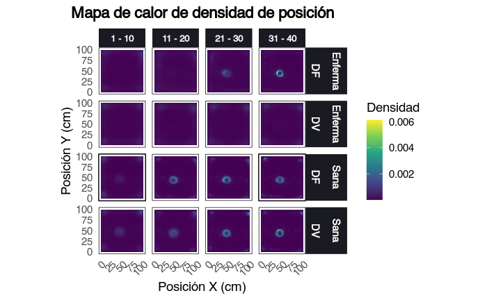

```r
# Function to plot position density heatmap with session groups
plot_position_density_heatmap <- function(data, n_sessions = 10) {
  data <- data %>%
    mutate(session_group = paste(
      (ceiling(session / n_sessions) - 1) * n_sessions + 1,
      "-",
      ceiling(session / n_sessions) * n_sessions
    ))

  ggplot(data, aes(x = X, y = Y)) +
    stat_density_2d(aes(fill = ..density..), geom = "tile", contour = FALSE, n = 100) +  # Increased n for higher resolution
    facet_grid(health_status + condition ~ session_group) +
    scale_fill_viridis_c() +
    labs(title = "Mapa de calor de densidad de posición",
         x = "Posición X (cm)",
         y = "Posición Y (cm)",
         fill = "Densidad") +
    theme_minimal(base_size = 14) +
    theme(
      plot.title = element_text(hjust = 0.5, face = "bold"),
      legend.position = "right",
      panel.grid = element_blank(),
      panel.border = element_rect(color = "black", fill = NA, size = 0.5),
      strip.background = element_rect(fill = color_palette[3], color = NA),
      strip.text = element_text(color = "white", face = "bold"),
      axis.text.x = element_text(angle = 45, hjust = 1),
      strip.text.x = element_text(size = 10)
    ) +
    coord_fixed(ratio = 1)
}

# Generate and save the plot with higher resolution
plot_position_density_heatmap(cleaned_data)
```

This position density heatmap provides important spatial insights about how both healthy (Sana) and VS-affected (Enferma) rats utilize the experimental space across different session groups (1-10, 11-20, 21-30, 31-40) and conditions (DF and DV).

Key observations:

1. Temporal Evolution (across session groups):
- Both groups show a progressive concentration of activity, with later sessions (31-40) displaying more focused hotspots, with the exception of the second’s row DV sick rats.
- This suggests learning and optimization of movement patterns over time
2. Group Differences:
- Healthy rats (Sana) show more concentrated, focused density patterns with distinct hotspots
- VS-affected rats (Enferma) display more diffuse patterns with less defined centers of activity
- This aligns with earlier findings about VS-affected rats showing larger, more variable movements
3. Condition Effects:
- DF (Fixed Distance) condition shows slightly more concentrated patterns compared to DV (Variable Distance)
- This makes sense given the predictable nature of fixed distance requirements
4. Spatial Organization:
- Both groups tend to develop central preferences in the space, at least for the DF case
- Healthy rats maintain more consistent spatial patterns
- VS-affected rats show broader spatial distribution, possibly reflecting their compromised spatial orientation, e.g., while healthy rats show clear spatial optimization (tighter hotspots) over sessions in both conditions, VS-affected rats show minimal improvement in spatial focusing during the DV condition. This suggests a specific difficulty with adapting to variable, more complex task demands.
- The stark difference between DF and DV conditions for VS-affected rats suggests that their spatial orientation difficulties are particularly pronounced when faced with variable, less predictable requirements

These spatial patterns complement the previous analyses by showing how the differences in movement characteristics (velocity, acceleration, displacement) manifest in actual space use, providing a more complete picture of how vestibular syndrome affects behavioral adaptation and spatial learning. The lack of optimization in the DV case for the VS-affected rats also provides important evidence that vestibular syndrome not only affects basic movement parameters but specifically impairs the ability to optimize movement patterns in more complex, variable conditions - a crucial insight for understanding the full impact of vestibular dysfunction on motor learning and adaptation.

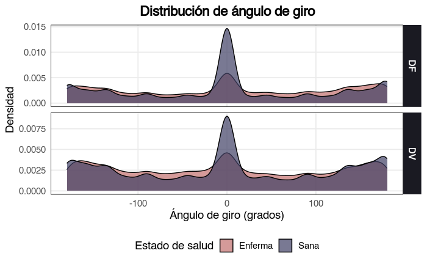

```r
# Function to plot turning angle distribution
plot_turning_angle_distribution <- function(data) {
  data[, turning_angle := atan2(Velocity_Y * shift(Velocity_X) - Velocity_X * shift(Velocity_Y),
                                Velocity_X * shift(Velocity_X) + Velocity_Y * shift(Velocity_Y)) * (180 / pi),
       by = .(rat, condition, session, health_status)]

  data[, turning_angle := remove_outliers(turning_angle),
       by = .(rat, condition, session, health_status)]

  ggplot(data, aes(x = turning_angle, fill = health_status)) +
    geom_density(alpha = 0.7) +
    facet_grid(condition ~ ., scales = "free_y") +
    scale_fill_manual(values = color_palette[c(1, 4)]) +
    labs(title = "Distribución de ángulo de giro",
         x = "Ángulo de giro (grados)",
         y = "Densidad",
         fill = "Estado de salud") +
    theme_minimal(base_size = 14) +
    theme(
      plot.title = element_text(hjust = 0.5, face = "bold"),
      legend.position = "bottom",
      panel.grid.minor = element_blank(),
      panel.border = element_rect(color = "black", fill = NA, size = 0.5),
      strip.background = element_rect(fill = color_palette[3], color = NA),
      strip.text = element_text(color = "white", face = "bold")
    ) +
    coord_cartesian(xlim = c(-180, 180))
}

plot_turning_angle_distribution(cleaned_data)
```

The turning angle distribution plot reveals crucial differences in rotational movement patterns between healthy and VS-affected rats:

Key Observations:

1. Central Peak Characteristics:
- Healthy rats show a prominent peak at 0 degrees, indicating frequent straight-line movement
- VS-affected rats demonstrate a notably lower central peak in both DF and DV conditions
- This suggests VS-affected rats maintain straight trajectories less frequently
2. Distribution Width:
- VS-affected rats show wider, more uniform distributions across all angles (-180° to +180°)
- This broader spread indicates more varied turning behaviors and less directional consistency
- The flatter distribution suggests less controlled or more random turning patterns
3. Condition Comparison (DF vs DV):
- Both groups show reduced peak heights in the DV condition
- The spread pattern remains consistently wider for VS-affected rats in both conditions
- This indicates that turning behavior impairment is a fundamental characteristic of VS, independent of task conditions

These patterns suggest that VS fundamentally affects directional control and turning behavior, with VS-affected rats showing: - Less ability to maintain straight trajectories - More variable and less controlled turning patterns - Consistent impairment across different task conditions

This turning angle analysis provides important insights into how vestibular dysfunction affects not just linear movement but also rotational control and directional stability.

```r
t_test_turning_df <- t.test(turning_angle ~ health_status, data = cleaned_data, subset = condition == "DF")

t_test_turning_dv <- t.test(turning_angle ~ health_status, data = cleaned_data, subset = condition == "DV")

print(t_test_turning_df)
```

```
    Welch Two Sample t-test

data:  turning_angle by health_status
t = 8.1081, df = 319203, p-value = 5.159e-16
alternative hypothesis: true difference in means between group Enferma and group Sana is not equal to 0
95 percent confidence interval:
 2.215132 3.627457
sample estimates:
mean in group Enferma    mean in group Sana
             5.731676              2.810382
```

```r
print(t_test_turning_dv)
```

```
    Welch Two Sample t-test

data:  turning_angle by health_status
t = -11.489, df = 291355, p-value < 2.2e-16
alternative hypothesis: true difference in means between group Enferma and group Sana is not equal to 0
95 percent confidence interval:
 -5.122219 -3.629306
sample estimates:
mean in group Enferma    mean in group Sana
            -2.539157              1.836605
```

These t-test results for turning angles reveal significant statistical differences between healthy and VS-affected rats, with some fascinating contrasts between conditions:

Fixed Distance (DF) Condition:

1. VS-affected rats show a higher mean turning angle (5.73° vs 2.81° for healthy rats)

2. The difference is highly significant (p = 5.159e-16)

3. The 95% CI [2.22°, 3.63°] indicates a consistent positive difference

4. Large sample size (df = 319,203) provides robust statistical power

Variable Distance (DV) Condition:

1. Interestingly, the pattern reverses: VS-affected rats show negative mean turning (-2.54° vs 1.84° for healthy)

2. Even stronger statistical significance (p < 2.2e-16)

3. The 95% CI [-5.12°, -3.63°] shows a substantial negative difference

4. Similarly large sample size (df = 291,355)

Key Insights:

This statistical evidence strongly supports the visual patterns seen in the turning angle distributions and adds important nuance about directional preferences in different conditions.

# Some concerns

Delving into this analysis has been both enlightening and challenging. As I’ve progressed through the data, examining the behavior of healthy rats against those with vestibular syndrome (VS) across various conditions, several key aspects have emerged that require a nuanced approach to ensure the robustness and reliability of our findings.

First and foremost, the sheer volume of data—nearly 800,000 samples—presents both opportunities and obstacles. On one hand, large datasets lend themselves to powerful statistical analyses and can reveal subtle patterns that might otherwise go unnoticed. On the other hand, managing and interpreting such extensive data requires careful consideration to avoid misleading conclusions.

One area where this is particularly pertinent is in the preprocessing stage, specifically in handling outliers. Initially, I employed a 1.5 interquartile range (IQR) rule to identify and remove outliers in displacement, velocity, and acceleration magnitudes. While this method is straightforward and widely used, I’ve begun to question its suitability for movement data, which often exhibit heavy-tailed distributions. In other words, movement data can have more extreme values than would be expected under a normal distribution, and thus, a rigid application of the IQR rule might inappropriately discard valid data points.

To address this, I’m considering adopting more sophisticated outlier detection techniques that are better suited to the characteristics of movement data. For instance, using domain knowledge to define what constitutes an outlier could be more effective. Alternatively, employing robust statistical methods that are less sensitive to outliers, such as median-based approaches or winsorizing extreme values, might offer a more balanced perspective.

Moving on to summarizing the data, while mean, median, standard deviation, and interquartile range provide a solid foundation, they may not capture the full complexity of the datasets, especially given the presence of multiple peaks in the velocity distributions. These multiple peaks could indicate distinct movement modes or behaviors, such as periods of slow exploration versus bursts of rapid movement.

To gain deeper insights into these patterns, I’m exploring techniques like kernel density estimation (KDE) and mixture modeling. KDE can help visualize the distribution of data points and identify areas of high density, which might correspond to preferred movement velocities or displacements. Mixture modeling, on the other hand, could allow us to decompose the data into its constituent subpopulations, potentially revealing different behavioral states or movement strategies employed by the rats.

Another critical aspect is the choice of statistical tests for comparing groups. Several issues arise with using t-tests in our context. First, our data often deviate from normality, which violates one of the key assumptions of t-tests. More crucially, however, is the problem of temporal autocorrelation in our movement data. Successive measurements of velocity, acceleration, and position are not independent of each other – a rat’s position at one moment is strongly influenced by its position in the previous moment, and the same applies to its velocity and acceleration.

This temporal dependence violates a fundamental assumption of the t-test: the independence of observations. When observations are autocorrelated, the effective sample size is smaller than the actual number of data points, leading to artificially small p-values and an increased risk of Type I errors (false positives). In other words, we might conclude there are significant differences between healthy and VS rats when there aren’t any.

To address this issue, several approaches could be considered. One option is to use mixed-effects models that can account for the temporal structure of the data. Another approach would be to subsample the data at intervals large enough to ensure independence between observations, though this would reduce our effective sample size. Alternatively, we could employ time series analysis techniques that explicitly model the autocorrelation structure.

Moreover, the analysis of turning angles presents a unique challenge due to the circular nature of angular data. Initially, I applied t-tests to compare turning angles between healthy and VS rats, but I’m increasingly aware that this may not be the most appropriate approach. Turning angles are angular data, which have inherent circular properties; for example, 0 degrees and 360 degrees are identical, but a t-test does not account for this circularity.

To handle circular data appropriately, specialized statistical methods are necessary. One such test is the Watson-Williams test, which is designed to compare mean directions between two or more groups while considering the circular nature of the data. Incorporating such tests would enhance the validity of our comparisons and provide more reliable insights into how vestibular syndrome affects turning behaviors.

The position density heatmaps have visually demonstrated differences in spatial distribution between healthy and VS rats, with healthy rats showing more focused hotspots and VS rats exhibiting more diffuse patterns. While these visual comparisons are informative, quantifying these differences would strengthen our analysis. To this end, I’m considering measures such as spatial entropy or fractal dimensions.

Spatial entropy can capture the randomness or disorder in the spatial distribution of movements, with higher entropy indicating more dispersed activity. Fractal dimensions, on the other hand, can quantify the complexity and self-similarity of movement patterns, potentially revealing how efficiently rats explore their environment. By calculating these metrics, we can obtain objective, numerical comparisons that complement the visual insights from the heatmaps.